# Final Project

Bernardo Gómez Romero

Fermín Alejandro Moreno Cornejo

11-26-2018

### Part I

First, we import all needed libraries and clean the environment

```r
library(quantmod)
library(dplyr)
library(quadprog)
library(PerformanceAnalytics)
library(IntroCompFinR)
rm(list=ls())
```

## Option Validation

We start by downloading prices for MSFT

```r
tickers.list <- c("MSFT")
for (t in tickers.list){
  try(getSymbols(t,
                 from = "2017-11-07",
                 periodicity = "weekly",
                 src = "yahoo") )
}
objList <- lapply(tickers.list, get)
prices.zoo <- do.call(merge, objList)
returns.df <-as.data.frame(diff(log(Ad(prices.zoo))))
tickers.list <- as.list(tickers.list)
colnames(returns.df)<-tickers.list
```

First 6 values of the continiuosly compounded returns (CCR)

```
##                    MSFT
## 2017-11-06           NA
## 2017-11-13 -0.017682655
## 2017-11-20  0.015392359
## 2017-11-27  0.011938962
## 2017-12-04 -0.001187407
## 2017-12-11  0.031462670
```

With the CCR we calculate the variance-covariance matrix, and the expected returns

```r
COV <- var(returns.df, na.rm = TRUE)
ER <- exp(colMeans(returns.df, na.rm=TRUE)) - 1
```

With the variance-covariance matrix and the expected returns we can calculate the global minimum variance portfolio

```r
gmvport <- globalMin.portfolio(ER, COV)
```

With the global minimum variance portfolio we can calculate the volatility

```r
volatility <- as.numeric(gmvport[3])
volatility_annual <- volatility * sqrt(52)
```

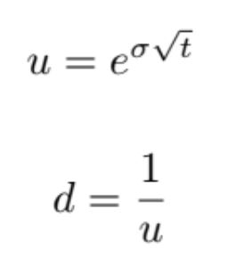

Formulas to calculate u & d

```r
u <- exp(volatility)
d <- 1/u
```

Then, we need to calculate the annual risk-free rate

```r
getSymbols("TB3MS",
           src = "FRED")
```

```
## [1] "TB3MS"
```

```r
Rf <- as.numeric(tail(TB3MS, 1))/52/100
RfAnnual <- Rf * 52

# S0 is today's value of the stock
S0 <- as.numeric(tail(Ad(prices.zoo), 1))
# Time to expiration date in years
t <- 1
```

### Option pricing with a multiperiod binomial model

We created a function to replicate the multiperiod binomial model, using all the data that we previously calculated and downloaded

```r
# input:
# call or put (option), initial stock price (S), growth factor (u), decline factor (d),
# risk-free rate (Rf), number of simulations (n)
multiperiod_binomial <- function(option, S0, u, d, Rf, n) {
  if (option != "call" && option != "put"){
    return("error, option must be 'call' or 'put'")
  }
  cat("\n Parameters:","\n option:",option, ", S0:", S0, ", u:", u,
      ", d:", d, ", Rf:", Rf, ", n:", n, "\n")
  # r: growth factor for risk-free investment.
  r = (1 + Rf)
  cat("\n r:",r)
  # q: f(u, d, r), prob of stock price going up
  q = (r - d) / (u - d)
  cat("\n q:", q)
  # K: strike price (any value K > S)
  K = S0 * 1.05
  cat("\n K:", K)
  acum_call_put = 0
  for (i in (1:n)) {
    S = S0
    # t: number of periods (weeks)
    t = 52
    for (j in (1:t)) {
      # state: random boolan variable to decide whether the price is going up or down.
      state = rbinom(1, 1, q)
      # calculate the stock price of the period
      # B0: risk-free bond, N: number of shares of the stock.
      if (state) {
        # Cu = (r * B0) + (N * u * S)
        S = S * u
      }
      else {
        # Cd = (r * B0) + (N * d * S)
        S = S * d
      } # end if state
    } # end for t

    if (option == "call"){
      # multiperiod binomial call
      call_put = max(0, (S-K))
    } else if (option == "put"){
      # multiperiod binomial put
      call_put = max(0, (K-S))
    }
    acum_call_put = acum_call_put + call_put
  } # end for n
  avrg_call_put = acum_call_put / n
  cat("\n average", option, ": ", avrg_call_put)
  # call_0: Present Value of avrg_call = avrg_call / (1 + Rf) ^ 52
  call_put_0 = avrg_call_put / (r ^ t)
  cat("\n present",option,"value:", call_put_0)
}
```

Multiperiod binomial function tests

```r
# test with incorrect option parameters
multiperiod_binomial("call error", S0, u, d, Rf, 1000)
```

```
## [1] "error, option must be 'call' or 'put'"
```

```r
# test call
multiperiod_binomial("call", S0, u, d, Rf, 1000)
```

```
##
##  Parameters:
##  option: call , S0: 106.47 , u: 1.026518 , d: 0.9741674 , Rf: 0.0004326923 , n: 1000
##
##  r: 1.000433
##  q: 0.5017227
##  K: 111.7935
##  average call :  6.62674
##  present call value: 6.479335
```

```r
# test put
multiperiod_binomial("put", S0, u, d, Rf, 1000)
```

```
##
##  Parameters:
##  option: put , S0: 106.47 , u: 1.026518 , d: 0.9741674 , Rf: 0.0004326923 , n: 1000
##
##  r: 1.000433
##  q: 0.5017227
##  K: 111.7935
##  average put :  9.88772
##  present put value: 9.667777
```

### Option pricing with Black and Sholes model

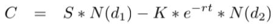

Black and Sholes call formula

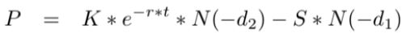

Black and Sholes put formula

We created a function to replicate the Black and Sholes model, using all the data that we previously calculated and downloaded

```r
d1 <- function(sd, S, k, r, t) {
  (log(S/k) + (r + ((sd^2) / 2)) * t) / (sd * sqrt(t))
}

d2 <- function(sd, S, k, r, t) {
  d1(sd, S, k, r, t) - (sd * sqrt(t))
}

black_sholes <- function(option, S, sd, RfAnnual, t){
  cat("\n Parameters:","\n option:",option, ", S0:", S, ", RfAnnual:", RfAnnual, ", t:", t, "\n")
  # K: strike price (any value K > S)
  K = S0 * 1.05
  cat("\n K:", K)
  if(option == "call"){
    result = (S * pnorm(d1(sd, S, K, RfAnnual, t))) - (K * exp(-RfAnnual * t) * pnorm(d2(sd, S, K, RfAnnual, t)))
  }else if(option == "put"){
    result = (K * exp(-RfAnnual * t) * pnorm(-d2(sd, S, K, RfAnnual, t))) - (S * pnorm(-d1(sd, S, K, RfAnnual, t)))
  }else return("error, option must be 'call' or 'put'")
  cat("\n",option,"value:", result)
}
```

Testing the Black and Sholes formula

```r
# test with incorrect option parameters
black_sholes("call error", S0, volatility_annual, RfAnnual, t)
```

```
##
##  Parameters:
##  option: call error , S0: 106.47 , RfAnnual: 0.0225 , t: 1
##
##  K: 111.7935
```

```
## [1] "error, option must be 'call' or 'put'"
```

```r
# test call
black_sholes("call", S0, volatility_annual, RfAnnual, t)
```

```
##
##  Parameters:
##  option: call , S0: 106.47 , RfAnnual: 0.0225 , t: 1
##
##  K: 111.7935
##  call value: 6.771317
```

```r
# test put
black_sholes("put", S0, volatility_annual, RfAnnual, t)
```

```
##
##  Parameters:
##  option: put , S0: 106.47 , RfAnnual: 0.0225 , t: 1
##
##  K: 111.7935
##  put value: 9.60755
```

## Part II

Instalation of quantstrat:

```r
# install.packages("devtools")
# require(devtools)
# devtools::install_github("braverock/blotter") # dependency
# devtools::install_github("braverock/quantstrat")
```

We add the needed libraries:

```r
library(quantmod)
library(quantstrat)
library(dplyr)
library(quadprog)
library(PerformanceAnalytics)
library(FinancialInstrument)
```

Cleaning the environment:

```r
rm(list=ls())
```

Declare the DVO function

```r
DVO <- function(HLC, navg = 2, percentlookback = 126) {
  # Compute the ratio between closing prices to the average of high and low
  ratio <- Cl(HLC)/((Hi(HLC) + Lo(HLC))/2)
  # Smooth out the ratio outputs using a moving average
  avgratio <- SMA(ratio, n = navg)
  # Convert ratio into a 0-100 value using runPercentRank()
  out <- runPercentRank(avgratio, n = percentlookback, exact.multiplier = 1) * 100
  colnames(out) <- "DVO"
  return(out)
}
```

Set the portafolio parameters

```r
# set strategy, portfolio and account name
strategy.st <- portfolio.st <- account.st <- "teamstrat"
tradesize_initeq = 100000
symbol = "MSFT"
# SMA: Simple Moving Average
SMA_big = 200
SMA_small = 50
# RSI: Relative Strength Index
RSI_x = 3
# DVO: David Varadi Oscillator
DVO_x = 2
# An initialization date for the backtest
initdate <- "2005-01-01"
# The start of the data
from <- "2010-01-01"
# The end of the data
to <- "2018-11-20"
```

Retrieve symbol from yahoo

```r
getSymbols(symbol, from=from, to=to, src="yahoo", adjust=TRUE)
```

```
## [1] "MSFT"
```

We defined a portfolio strategy function to make it easier to adjust the strategy parameters and find better combinations for the indicators, signals and rules.

```r
BuildPortfolioStrategy <- function(tradesize_initeq, symbol, initdate, SMA_big, SMA_small, RSI_x, DVO_x) {
  # Define the trade size and initial equity
  # param: tradesize_initeq
  tradesize <- tradesize_initeq
  initeq <- tradesize_initeq

  # Define the names of the strategy, portfolio and account
  strategy.st <- portfolio.st <- account.st <- "teamstrat"

  # Remove the existing portfolio and strategy if it exists
  rm.strat(portfolio.st)
  rm.strat(strategy.st)

  Sys.setenv(TZ = "UTC")
  currency("MXN")

  # Use stock() to initialize symbol and set currency to MXN
  # param: symbol
  stock(symbol, currency = "MXN")

  # Initialize the portfolio
  initPortf(portfolio.st, symbols = symbol, initDate = initdate, currency = "MXN")

  # Initialize the account
  initAcct(account.st, portfolios = portfolio.st, initDate = initdate, currency = "MXN", initEq = initeq)

  # Initialize the orders
  initOrders(portfolio.st, initDate = initdate)

  strategy(strategy.st, store=TRUE)

  # -------------------- Add Indicators --------------------

  # Add a X-day SMA indicator to strategy.st (big)
  # param: SMA_big
  add.indicator(strategy = strategy.st,
                # Add the SMA function
                name = "SMA",
                # Create a lookback period
                arguments = list(x = quote(Cl(mktdata)), n = SMA_big),
                # Label the indicator SMA_big
                label = "SMA_big")

  # Add a Y-day SMA indicator to strategy.st (small, X > Y)
  # param: SMA_small
  add.indicator(strategy = strategy.st,
                # Add the SMA function
                name = "SMA",
                # Create a lookback period
                arguments = list(x = quote(Cl(mktdata)), n = SMA_small),
                # Label the indicator SMA_small
                label = "SMA_small")


  # Add an RSI X indicator to strategy.st
  # param: RSI_x
  add.indicator(strategy = strategy.st,
                # Add the RSI function
                name = "RSI",
                # Create a lookback period
                arguments = list(price = quote(Cl(mktdata)), n = RSI_x),
                # Label the indicator RSI_x
                label = "RSI_x")

  # Add the DVO indicator to the strategy
  # param: DVO_x
  add.indicator(strategy = strategy.st, name = "DVO",
                arguments = list(HLC = quote(HLC(mktdata)), navg = DVO_x, percentlookback = 126),
                label = "DVO_x_126")


  # -------------------- Add Signals --------------------

  # Add a sigComparison which specifies that SMA50 must be greater than SMA200, call it longfilter
  add.signal(strategy.st, name = "sigComparison",
             # We are interested in the relationship between the SMA50 and the SMA200
             arguments = list(columns = c("SMA_small", "SMA_big"),
                              # Particularly, we are interested when the SMA50 is greater than the SMA200
                              relationship = "gt"),
             # Label this signal longfilter
             label = "longfilter")

  # Add a sigCrossover which specifies that the SMA50 is less than the SMA200 and label it filterexit
  add.signal(strategy.st, name = "sigCrossover",
             # We're interested in the relationship between the SMA50 and the SMA200
             arguments = list(columns = c("SMA_small", "SMA_big"),
                              # The relationship is that the SMA50 crosses under the SMA200
                              relationship = "lt"),
             # Label it filterexit
             label = "filterexit")

  # Implement a sigThreshold which specifies that DVO_x_126 must be less than 20, label it longthreshold
  add.signal(strategy.st, name = "sigThreshold",
             # Use the DVO_x_126 column
             arguments = list(column = "DVO_x_126",
                              # The threshold is 20
                              threshold = 20,
                              # We want the oscillator to be under this value
                              relationship = "lt",
                              # We're interested in every instance that the oscillator is less than 20
                              cross = FALSE),
             # Label it longthreshold
             label = "longthreshold")

  # Add a sigThreshold signal to the strategy that specifies that DVO_x_126 must cross above 80 and label it thresholdexit
  add.signal(strategy.st, name = "sigThreshold",
             # Reference the column of DVO_x_126
             arguments = list(column = "DVO_x_126",
                              # Set a threshold of 80
                              threshold = 80,
                              # The oscillator must be greater than 80
                              relationship = "gt",
                              # We are interested only in the cross
                              cross = TRUE),
             # Label it thresholdexit
             label = "thresholdexit")

  # Create the dataset: test
  test_init <- applyIndicators(strategy.st, mktdata = OHLC(get(symbol)))
  test <- applySignals(strategy = strategy.st, mktdata = test_init)

  # Add a sigFormula signal to the code specifying that both longfilter and longthreshold must be TRUE, label it longentry
  add.signal(strategy.st, name = "sigFormula",
             # Specify that longfilter and longthreshold must be TRUE
             arguments = list(formula = "longfilter & longthreshold",
                              # Specify that cross must be TRUE
                              cross = TRUE),
             # Label it longentry
             label = "longentry")


  # -------------------- Add Rules --------------------

  # Fill in the rule's type as exit
  add.rule(strategy.st, name = "ruleSignal",
           arguments = list(sigcol = "filterexit", sigval = TRUE, orderqty = "all",
                            ordertype = "market", orderside = "long",
                            replace = FALSE, prefer = "Open"),
           type = "exit")

  # Create an entry rule of 1 share when all conditions line up to enter into a position
  add.rule(strategy.st, name = "ruleSignal",
           # Use the longentry column as the sigcol
           arguments=list(sigcol = "longentry",
                          # Set sigval to TRUE
                          sigval = TRUE,
                          # Set orderqty to 1
                          orderqty = 1,
                          # Use a market type of order
                          ordertype = "market",
                          # Take the long orderside
                          orderside = "long",
                          # Do not replace other signals
                          replace = FALSE,
                          # Buy at the next day's opening price
                          prefer = "Open"),
           # This is an enter type rule, not an exit
           type = "enter")
}
```

### Build portafolio strategy with the defined parameters

```r
BuildPortfolioStrategy(tradesize_initeq, symbol, initdate, SMA_big, SMA_small, RSI_x, DVO_x)
```

### Analyze Results

```r
# Use applyStrategy() to apply the strategy. Save this to out
out <- applyStrategy(strategy = strategy.st, portfolios = portfolio.st)

# Update the portfolio (portfolio.st)
updatePortf(portfolio.st)
daterange <- time(getPortfolio(portfolio.st)$summary)[-1]

# Update the account (account.st)
updateAcct(account.st, daterange)
updateEndEq(account.st)

# Get the tradeStats for the portfolio
tstats <- tradeStats(Portfolios = portfolio.st)
```

Print the profit factor

```r
tstats$Profit.Factor
```

```
## [1] 12.8818
```

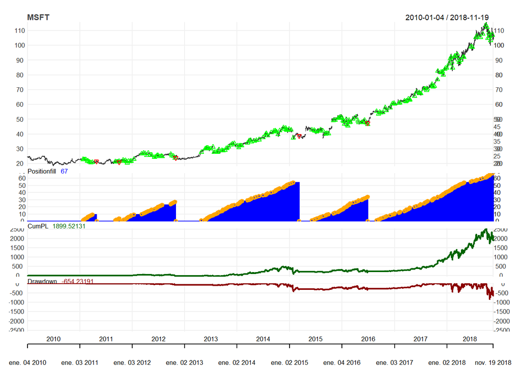

```r
# Use chart.Posn to view the system's performance on the symbol
chart.Posn(Portfolio = portfolio.st, Symbol = symbol)
```

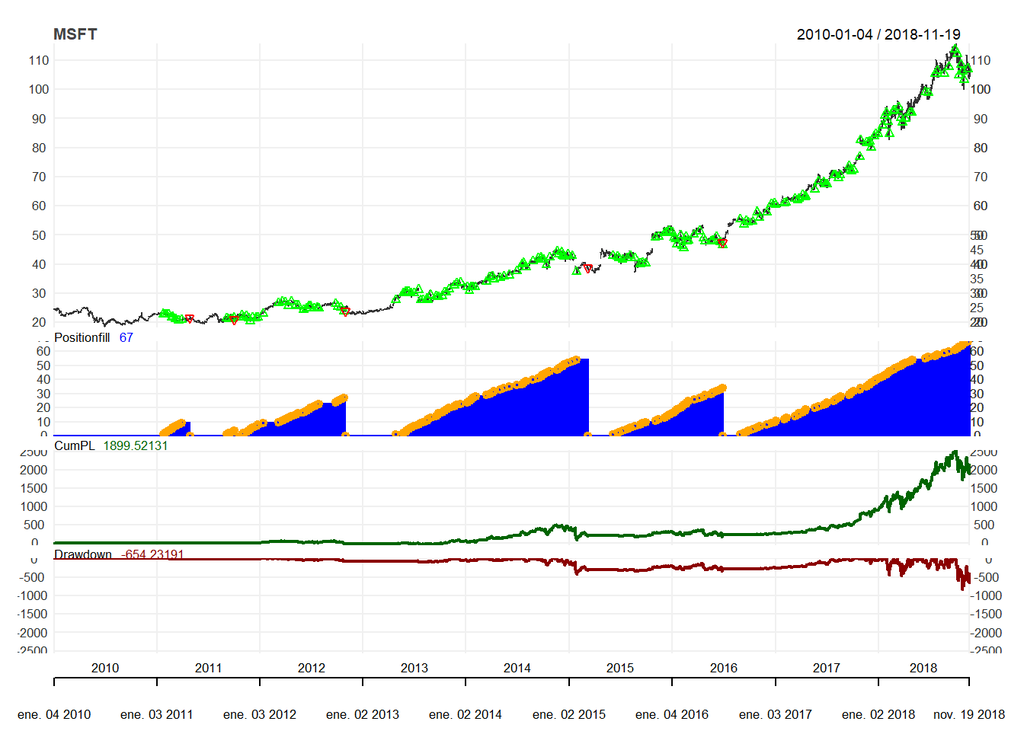

```r
# Compute the SMA_small
sma_s <- SMA(x = Cl(get(symbol)), n = SMA_small)

# Compute the SMA_big
sma_b <- SMA(x = Cl(get(symbol)), n = SMA_big)

# Compute the DVO_x_126 with an navg of DVO_x and a percentlookback of 126
dvo <- DVO(HLC = HLC(get(symbol)), navg = DVO_x, percentlookback = 126)

# Recreate the chart.Posn of the strategy from the previous exercise
chart.Posn(Portfolio = portfolio.st, Symbol = symbol)
```

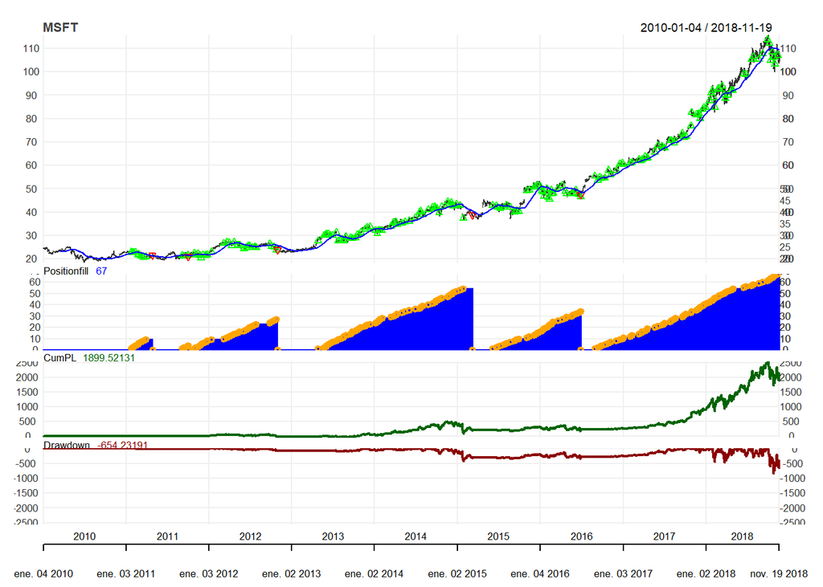

```r
# Overlay the sma_small on the plot as a blue line
add_TA(sma_s, on = 1, col = "blue")
```

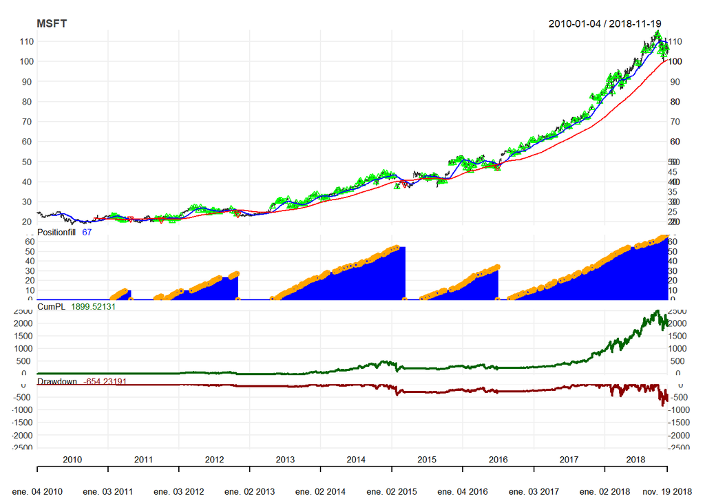

```r
# Overlay the SMA_big on the plot as a red line
add_TA(sma_b, on = 1, col = "red")
```

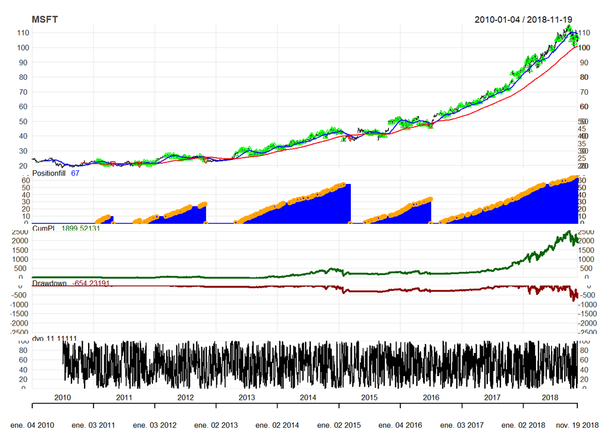

```r
# Add the DVO_x_126 to the plot in a new window
add_TA(dvo)
```

```r
# ---> Sharpe ratio

# Get instrument returns
instrets <- PortfReturns(portfolio.st)

# Compute Sharpe ratio from returns
SharpeRatio.annualized(instrets, geometric = FALSE)
```

```
##                                 MSFT.DailyEqPL
## Annualized Sharpe Ratio (Rf=0%)      0.4251517
```

### Compare strategy with different parameters:

```r
# SMA: Simple Moving Average
SMA_big = 150
SMA_small = 30
# RSI: Relative Strength Index
RSI_x = 4
# DVO: David Varadi Oscillator
DVO_x = 3
```

```
## tstats$Profit.Factor: 4.258949
```

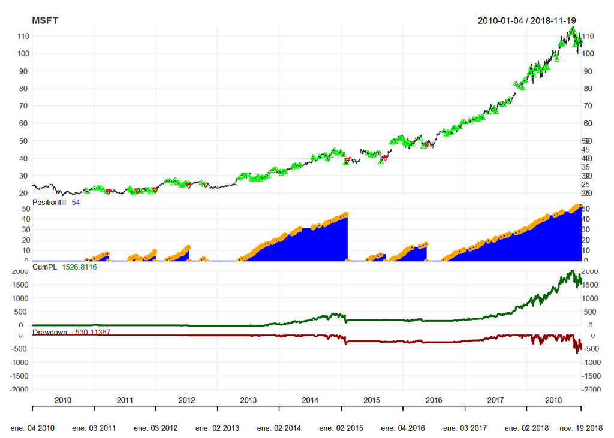

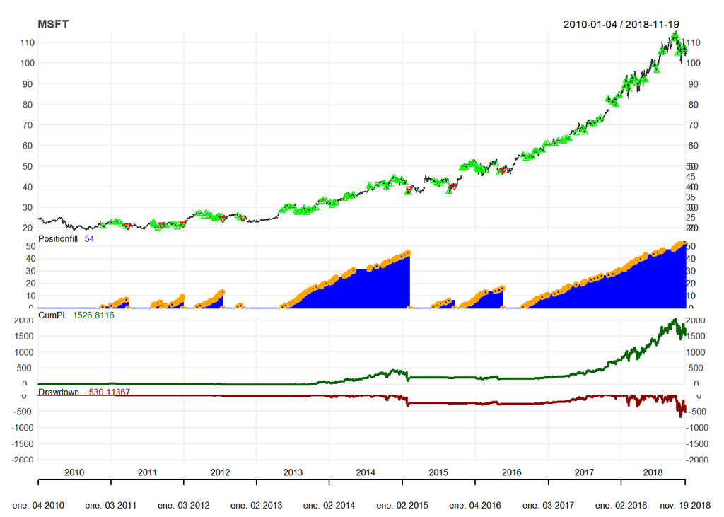

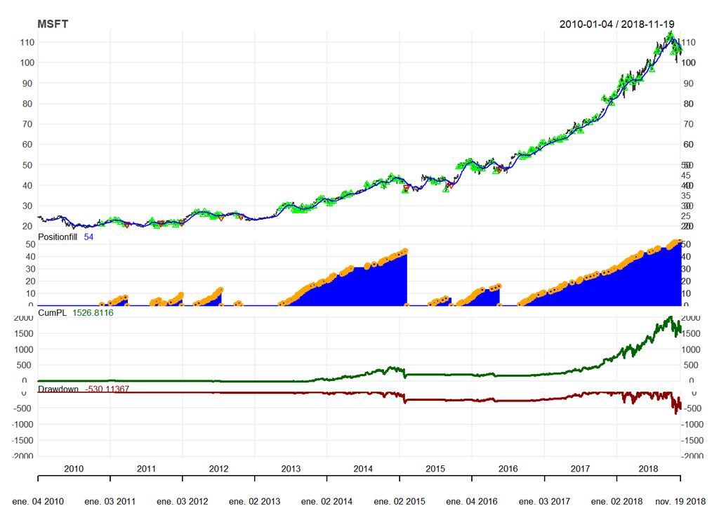

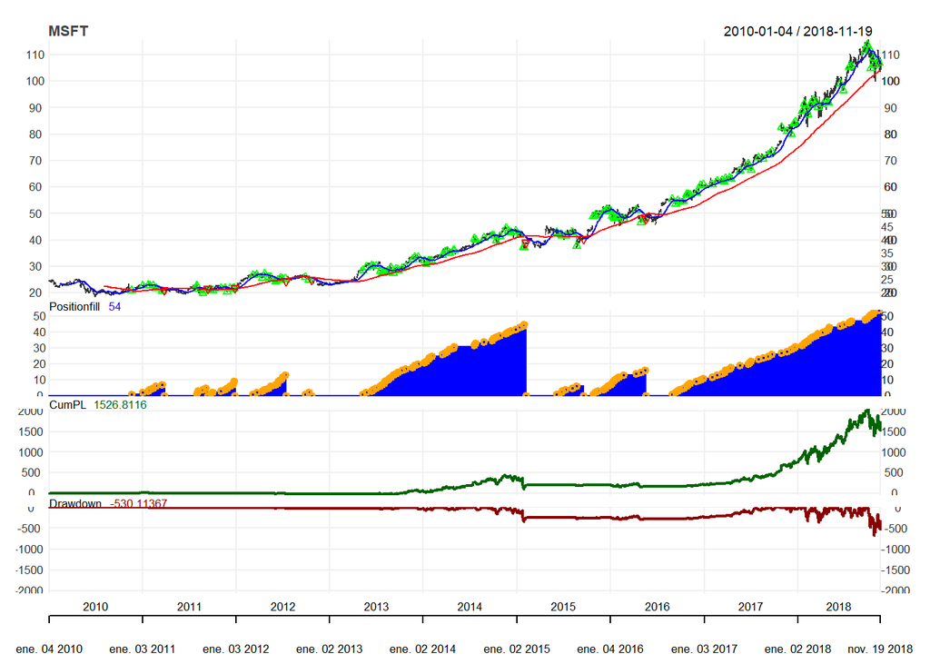

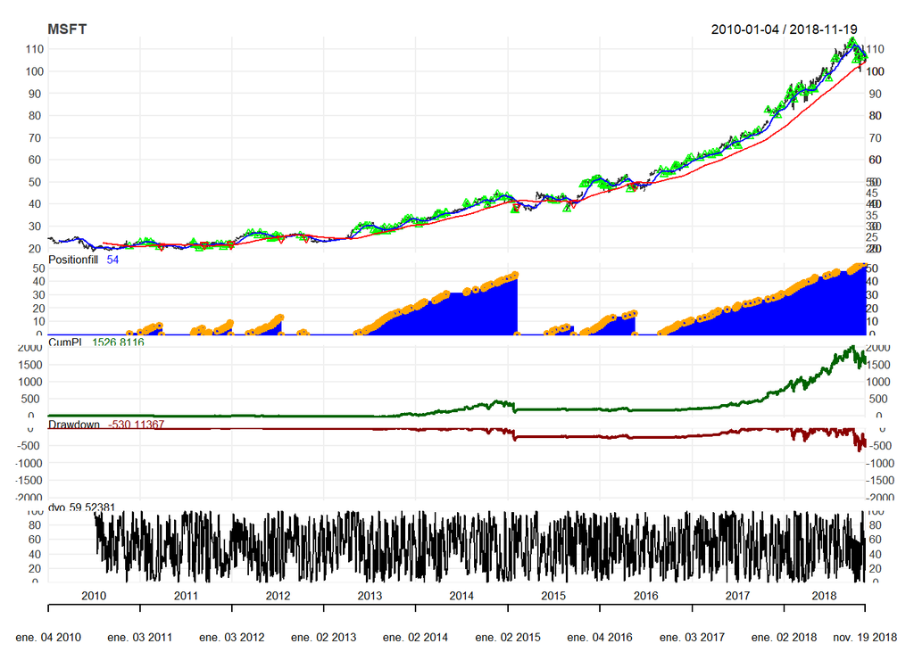

```
##                                 MSFT.DailyEqPL
## Annualized Sharpe Ratio (Rf=0%)      0.4336806
```

### Analyze results

IT was cvery usefull for us to have a modular program with the function because we could try different combinations of parameters to find the optimal strategy. The difference between the two set of parameters was that the 2nd one, the Simple Moving Average range was smaller and the RSI and DVO were higher. The results were:

#### Parameters Set 1:

##### tstats$Profit.Factor: 12.8818

##### Annualized Sharpe Ratio (Rf=0%): 0.4251517

#### Parameters Set 2:

##### tstats$Profit.Factor: 4.258949

##### Annualized Sharpe Ratio (Rf=0%): 0.4336806

The parameters set 1 had a significantly higher profit higher profit factor while the parameters set 2 had a slightly higher annualized sharpe ratio, the better set of parameters was the set 1.

### Part III

A Pythagorean triplet is a set of three natural numbers, a < b < c, for which a^2 + b^2 = c^2. Given an integer N, check if there exists a Pythagorean triplet for which a + b + c = N, return value: a * b * c if there exists such triplet, otherwise, return -1

```r
extra_points <- function(N){
  aux = 0
  for(a in (1:(N/3))){
    for(b in (a:(N/2))){
      c = N - a - b
      if((a*a + b*b) == (c*c)){
        return(a * b * c)
      }
    }
  }
  return(-1)
}
extra_points(1000)
```

```
## [1] 31875000
```